# F_Fox

### Looking at the data:

|  | Mo | From Plant | Business | Confirmation Date | Plan Date | Plan Type | Destination | Zone | Product Code | Total Nos. (Planned) | Total Weight (Planned) | Mode | Combine load\n (YES/NO) | Shipment Date | Total Weight (Actual) | Total Nos. (Actual) | Vehicle no |
| --- | --- | --- | --- | --- | --- | --- | --- | --- | --- | --- | --- | --- | --- | --- | --- | --- | --- |
| 0 | 2019-05-19 | K | O | 2019-05-17 00:00:00 | 2019-05-20 00:00:00 | Normal | Narsinghpura | NORTH | X40 | NaN | NaN | NaN | NO | 2019-05-21 | 8.0 | 2100.0 | RJ11GA7267 |
| 1 | 2019-04-19 | K | O | 2019-04-02 00:00:00 | 2019-04-03 00:00:00 | Normal | Mehsana | WEST | X40 | 2080.0 | 14046.0 | MXL | NO | 2019-04-04 | 14.0 | 2080.0 | RJ11GA7331 |
| 2 | 2019-04-19 | K | O | 2019-04-04 00:00:00 | 2019-04-05 00:00:00 | Normal | Narsinghpura | NORTH | X40 | 2080.0 | 14046.0 | MXL | NO | 2019-04-09 | 14.0 | 2080.0 | RJ11GA7368 |
| 3 | 2019-04-19 | K | O | 2019-04-08 00:00:00 | 2019-04-09 00:00:00 | Normal | Narsinghpura | NORTH | X40 | 1040.0 | 7023.0 | MXL | NO | 2019-04-11 | 7.0 | 2080.0 | RJ11GA3381 |
| 4 | 2019-04-19 | K | O | 2019-04-10 00:00:00 | 2019-04-11 00:00:00 | Normal | Mehsana | WEST | X40 | 2080.0 | 14046.0 | MXL | NO | 2019-04-12 | 14.0 | 2080.0 | RJ11GA7266 |

#### Different data types for the columns

```
Mo                         datetime64[ns]
From Plant                         object
Business                           object
Confirmation Date                  object
Plan Date                          object
Plan Type                          object
Destination                        object
Zone                               object
Product Code                       object
Total Nos. (Planned)              float64
Total Weight (Planned)            float64
Mode                               object
Combine load\n (YES/NO)            object
Shipment Date              datetime64[ns]
Total Weight (Actual)             float64
Total Nos. (Actual)               float64
Vehicle no                         object
dtype: object
```

#### Missing value percentage across columns

```
                         Missing_ratio
Total Weight (Planned)       52.798434
Total Nos. (Planned)         51.076321
Mode                         50.998043
Total Weight (Actual)        42.426614
Combine load\n (YES/NO)      30.919765
Plan Type                    30.606654
Total Nos. (Actual)          14.755382
Vehicle no                    1.800391
Zone                          0.900196
Confirmation Date             0.508806
Shipment Date                 0.352250
Destination                   0.273973
Plan Date                     0.273973
```

```
Describe numbers planned
 count    1250.000000
mean      536.988800
std       406.226733
min         1.000000
25%       200.000000
50%       422.500000
75%       898.250000
max      2080.000000
Name: Total Nos. (Planned), dtype: float64

Describe numbers Actual
 count    2178.000000
mean      633.224977
std       436.381596
min         1.000000
25%       240.000000
50%       562.500000
75%       940.000000
max      2100.000000
Name: Total Nos. (Actual), dtype: float64
```

# Insights 1.0

```
array(['narsinghpura', 'mehsana', 'bangalore', 'chennai', 'ahmedabad',
       'chennai - south'], dtype=object)
```

### 1. Cities that order most number of products.

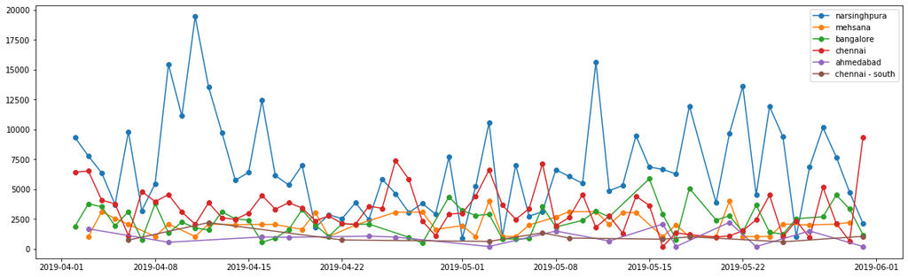

### 2. Plant shipping number of products on a given date.

1. K shipped more products through out two months. 7.5K to 25k products a day and sometime even 30k a day.
2. C stayed mostly in the 7.5-15k range with sometimes as low as 2.5k products a day.

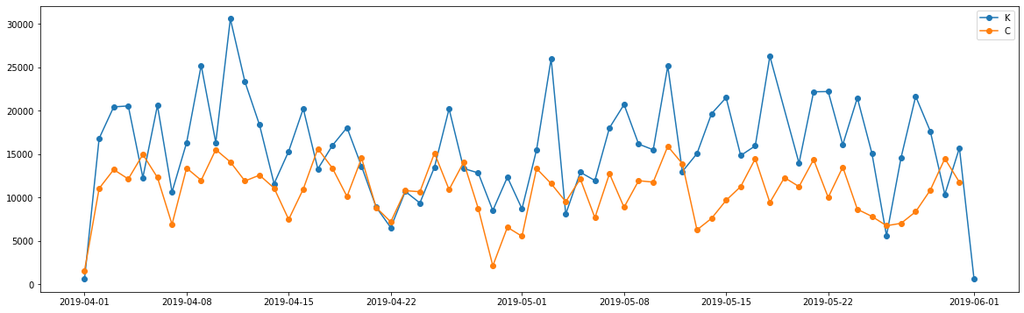

### 3. Similary for SKUs

1. Original equipments were shipped more. 10k-30 and sometime 35k a day.
2. Whereas Replacement equipment from 2.5k to 15k a day.

O stands for OEM (Original Equipment Manufacturer) while R stands for Replacement market.

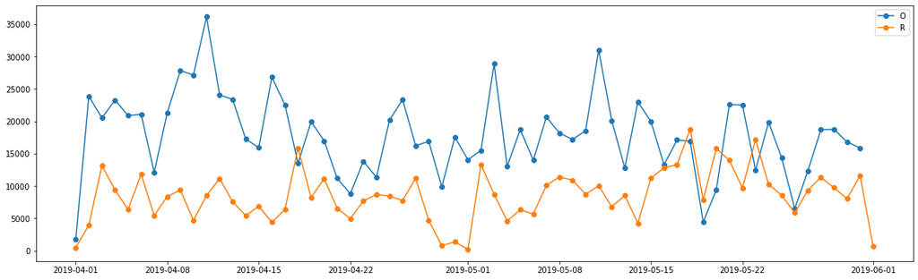

### 4. City wise, product distribution:

1. Narsinghpura ordered close to 95k X40, 90k X48 and so on.
2. Similarly for other cities graphs are shown.

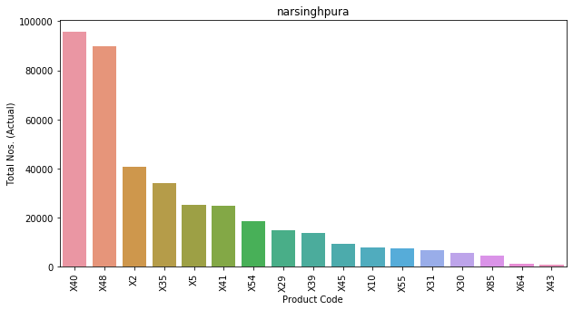

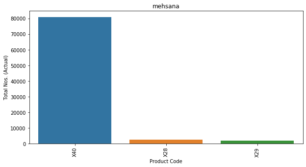

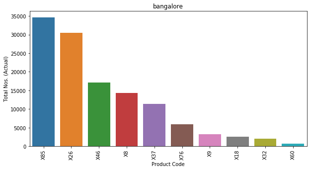

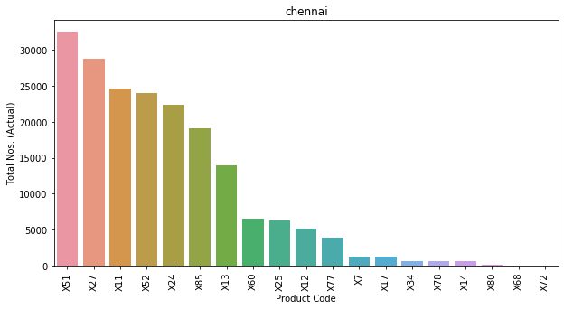

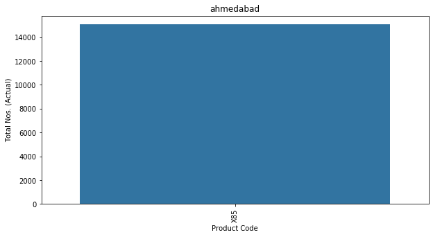

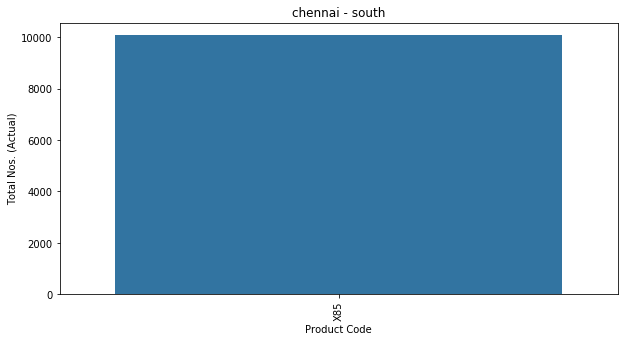

### 5. Similary, From plant and Business (number of different products shipped)

1. K shipped out more than 200k X85, 175k X40 and so on.
2. Original equipment: X40 - 175k times and so on. Replacement: X85 - More than 500k

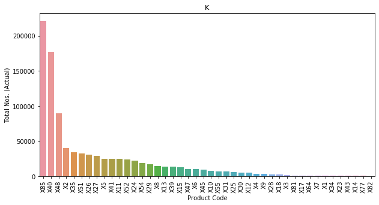

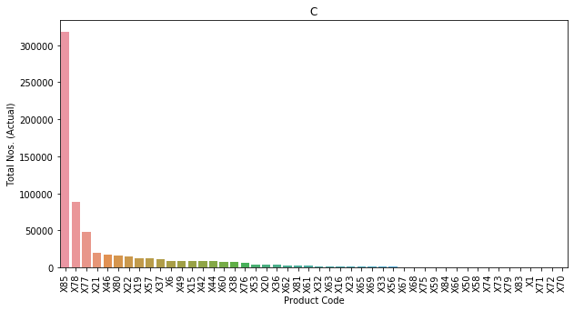

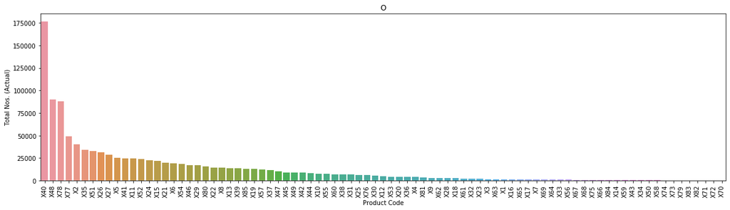

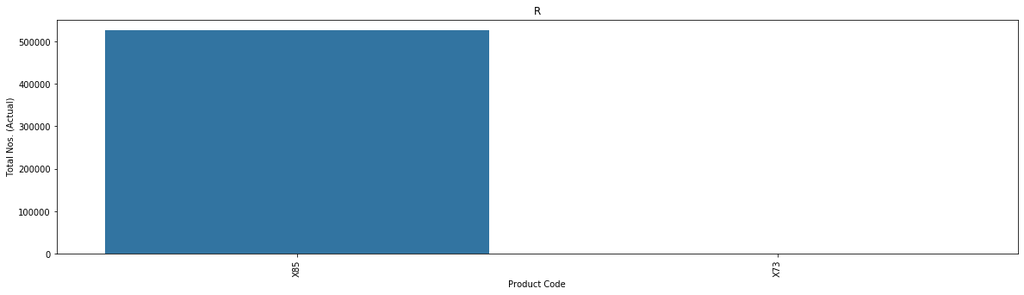

### 6. Top 5 products' total demand increase or decrease with time.

1. X85 stays in most demand and demand peaks once or twice a week more than usual. Need more data to validate though.

Checking groupby date and product code:

```
Shipment Date  Product Code
2019-04-01     X85               474.000000
2019-04-02     X85              3953.000000
2019-04-03     X85             13130.000000
2019-04-04     X85              9562.000000
2019-04-05     X85              6364.224977
                                   ...
2019-05-28     X85             11315.224977
2019-05-29     X85              9714.224977
2019-05-30     X85              8016.674931
2019-05-31     X85             11579.899908
2019-06-01     X85               630.000000
Name: Total Nos. (Actual), Length: 62, dtype: float64
```

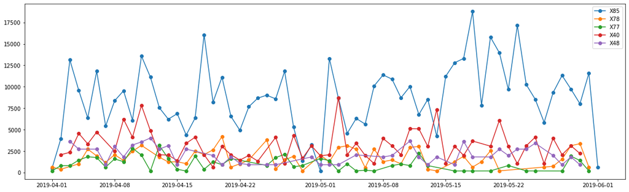

# Insights 1.1

### Difference in confirmation, planned and actual shipment date wrt to destinations, products codes, plants, business, vehicle type, number of products etc

## 1. Total number of articles shipped by different vehicle types, from different plants to different SKU.

#### 1.1 MF trucks were used throught out two months, NF only in May, CMF truck took constant number of products. Number of article ranged between 250-800 in April and 100-800 in May.

#### 1.2 MF, NF and CMF truck type usage behaviour is consitent with previous. Hence it is Plant driven.

#### 2.1 MF was used only in May,MXL in April, item numbers range from 500 - 1100.

#### 2.2 Most variety of trucks. Consistent with 2.1. Maybe plant K got access to MF truck in May. After they got MF in may, K did not use any other truck.

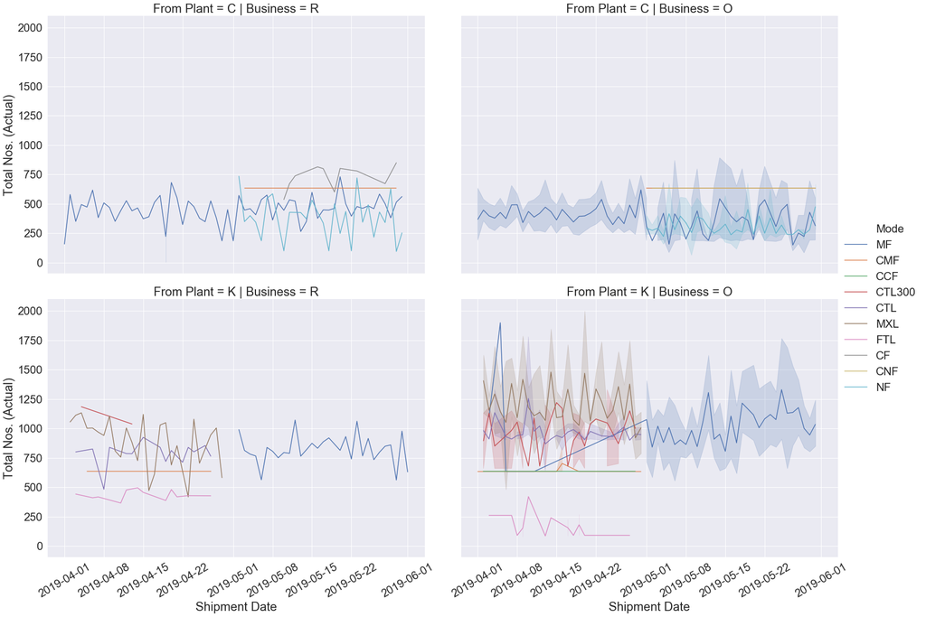

#### Understanding how multidimensional grouping works:

Number of trucks per day:

```
From Plant  Mode    Product Code
C           MF      X85             592
K           MF      X85             167
C           NF      X85              71
K           MXL     X85              55
            CTL     X85              25
            FTL     X85              19
C           CF      X85              14
K           CMF     X85               4
C           CMF     X85               4
K           CTL300  X85               2
C           CNF     X85               2
            CCF     X85               1
Name: Total Nos. (Actual), dtype: int64
```

Total number of article in those trucks:

```
From Plant  Mode    Product Code
C           MF      X85             274045.049587
K           MF      X85             138349.149679
            MXL     X85              49869.224977
C           NF      X85              28967.000000
K           CTL     X85              19785.000000
C           CF      X85              10246.000000
K           FTL     X85               7959.000000
            CMF     X85               2532.899908
C           CMF     X85               2532.899908
K           CTL300  X85               2223.000000
C           CNF     X85               1266.449954
            CCF     X85                633.224977
Name: Total Nos. (Actual), dtype: float64
```

```
Product Code
X85    538408.898990
X40    176322.574839
X48     89794.000000
X78     88202.422406
X77     49302.698806
           ...
X83       200.000000
X82        40.000000
X71        20.000000
X72         5.000000
X70         5.000000
Name: Total Nos. (Actual), Length: 85, dtype: float64
```

### Above you can see that significant number of X85 from total 5.38 lacs. Came from:

1. C using MF trucks. (2.74 lac using 592 trucks) (1 truck -> 462 items average)
2. K using MF and MXL trucks. (1.38 + 0.50 lac using (167 + 55) trucks) (1 truck -> 843 items on average) MF trucks from plant K carried almost double the number of products than C.

## 2. Introducing new dimension. Extra items shipped. (Actual - Planned)

```
Index(['X85', 'X78', 'X77', 'X40', 'X48', 'X21', 'X80', 'X6', 'X22', 'X15'], dtype='object')
```

### Mean extra items grouped by date, plant, mode, product, business.

|  | Shipment Date | From Plant | Mode | Product Code | Business | Extra items |
| --- | --- | --- | --- | --- | --- | --- |
| 3 | 2019-04-01 | C | MF | X85 | R | -378.988800 |
| 1 | 2019-04-01 | C | MF | X77 | O | -344.988800 |
| 0 | 2019-04-01 | C | MF | X62 | O | -256.988800 |
| 2 | 2019-04-01 | C | MF | X78 | O | 96.236177 |
| 4 | 2019-04-01 | K | CMF | X6 | O | 393.224977 |

|  | Shipment Date | From Plant | Mode | Product Code | Business | Extra items |
| --- | --- | --- | --- | --- | --- | --- |
| 1332 | 2019-05-31 | K | MF | X35 | O | 603.011200 |
| 1317 | 2019-05-31 | C | CMF | X75 | O | 625.224977 |
| 1331 | 2019-05-31 | K | MF | X24 | O | 853.011200 |
| 1334 | 2019-05-31 | K | MF | X51 | O | 963.011200 |
| 1336 | 2019-06-01 | K | MF | X85 | R | 93.011200 |

## Extra items per different products from plants to SKUs.

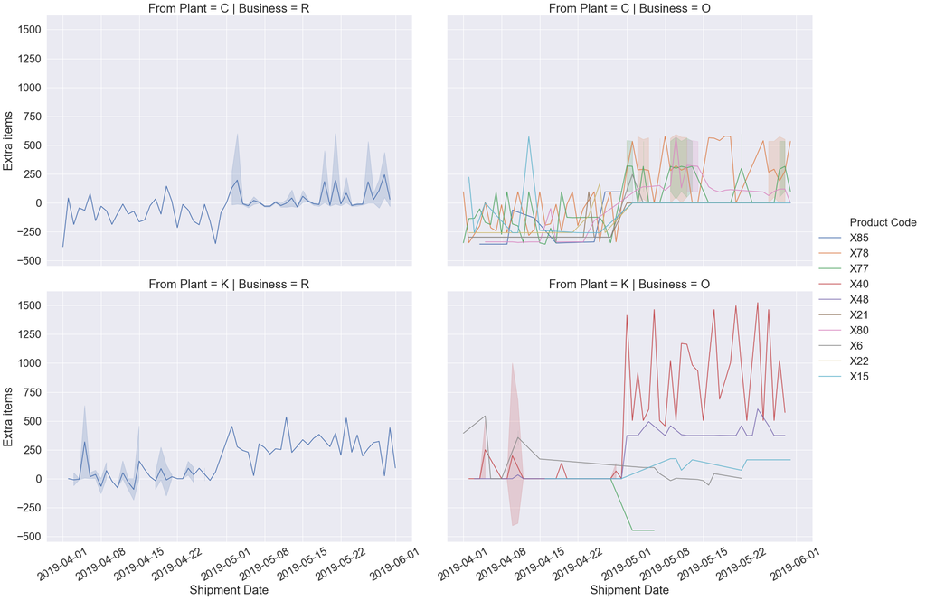

## Extra items carried by different *truck types* from plants to SKUs.

1. In April, Plant C delivered more using MF trucks and in May, Plant K used more MF trucks.
2. In May, Plant C shipped extra items majorly using CMF trucks.
3. In April, Plant K used a bunch of different trucks more than what Plant C used in May.
4. The increase in extra items in May is evident in this graph too as mentions earlier.

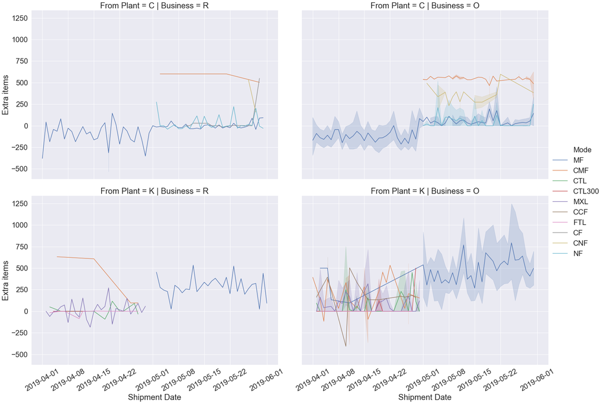

## Destination layer added to above dimensions impacting extra items.

|  | Shipment Date | Destination | From Plant | Business | Extra items |
| --- | --- | --- | --- | --- | --- |
| 3 | 2019-04-01 | kheda | C | R | -472.988800 |
| 1 | 2019-04-01 | hyderabad | C | R | -351.988800 |
| 4 | 2019-04-01 | nagpur | C | R | -311.988800 |
| 5 | 2019-04-01 | nasik | C | O | -256.988800 |
| 2 | 2019-04-01 | jamshedpur | C | O | -124.376311 |

### City wise:

1. Most extra items usually went to Mehsana followed by Bangalore and Chennai in May.
2. In April, Plant C shipped extra and less than planned almost equally to different cities. Ranging from -500 to 500 per day.
3. From Plant K, Replacement equipments shipped extra almost saw an upward trend from April beginning to May end.
4. Plant C shipped R items to more number of cities.

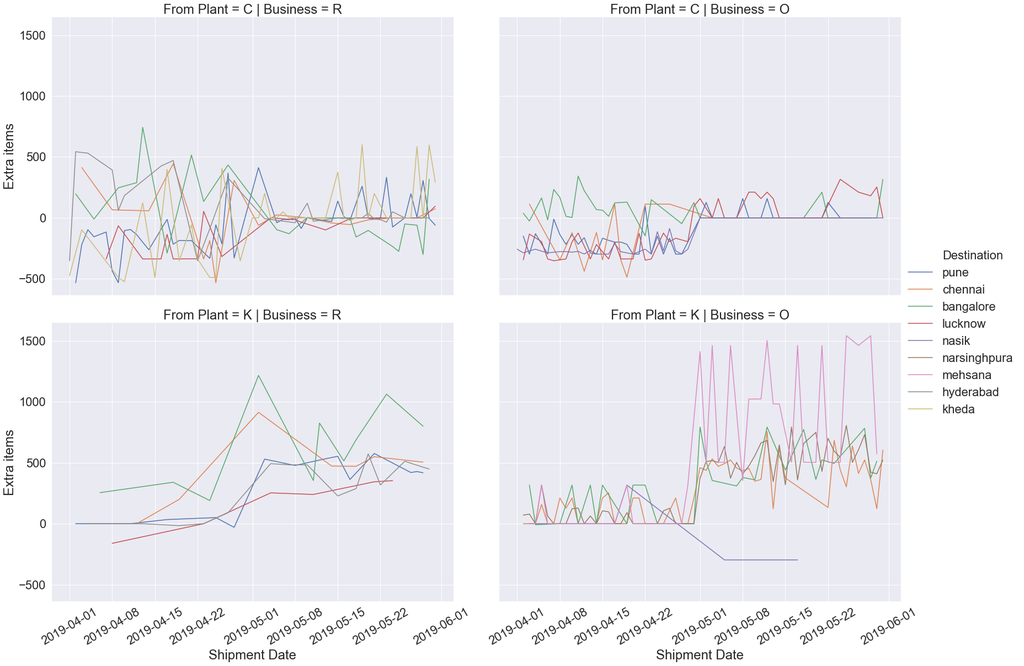

## 3. Introducing new dimension: Delay.

### Planning -> Planning - Confirmation date

### Shipment -> Shipment - Planning date

### Mean delay in shipment (Shipment - Planned date) wrt truck type:

```
Mode
CCF             2 days 00:00:00
CTL      1 days 21:40:57.931034
CTL300   1 days 12:27:41.538461
CF              1 days 01:36:00
MXL      1 days 00:07:34.736842
MF       0 days 08:16:15.700934
CMF      0 days 07:37:08.571428
FTL      0 days 06:17:08.571428
CNF      0 days 01:50:46.153846
NF       0 days 01:08:16.551724
Name: Delay planned, dtype: timedelta64[ns]
```

### Mean delay in planning (Planned - Confirmation date) wrt truck type:

```
Mode
CF              2 days 01:36:00
MXL      1 days 10:59:22.105263
NF       1 days 10:02:04.137931
CTL      1 days 09:16:08.275862
CTL300   1 days 06:55:23.076923
CCF             1 days 03:12:00
FTL      1 days 02:51:25.714285
CNF      1 days 01:50:46.153846
MF       0 days 17:07:51.028037
CMF      0 days 08:45:42.857142
Name: Planning days, dtype: timedelta64[ns]
```

### Mean delay in planning (Confirmed - Planned) present city wise.

```
Destination
delhi - south                            2 days 04:48:00
jammu                                    2 days 04:00:00
varanasi                          2 days 03:25:42.857142
zirakpur                                 2 days 00:00:00
parwanoo                                 2 days 00:00:00
                                          ...
tripunithura                             0 days 00:00:00
indore                          -1 days +17:22:45.517241
sanand                          -2 days +22:54:32.727272
pithampur                       -2 days +12:34:17.142857
tkml w-h charge with secondry         -37 days +00:00:00
Name: Planning days, Length: 70, dtype: timedelta64[ns]
```

```
Max and min delay in planning 4 days 00:00:00 and -37 days +00:00:00
```

```
Max and min delay in shipment 48 days 00:00:00 and -52 days +00:00:00
```

### Adding more dimensions to planning and shipment delays. (ie adding plant, businedd, product code information)

```
From Plant  Business  Product Code  Mode
K           O         X30           MF          3 days 00:00:00
                                    CTL300      3 days 00:00:00
                      X5            CCF         3 days 00:00:00
                      X64           MF          3 days 00:00:00
                      X18           CMF         2 days 12:00:00
                                                    ...
C           O         X63           MF          0 days 00:00:00
                      X84           MF          0 days 00:00:00
K           O         X47           MF        -7 days +00:00:00
                      X85           MF       -18 days +12:00:00
            R         X85           CMF      -22 days +06:00:00
Name: Planning days, Length: 215, dtype: timedelta64[ns]
```

```
From Plant  Business  Product Code  Mode
K           O         X47           MF          8 days 19:12:00
                      X28           CTL300      5 days 00:00:00
                      X35           MXL         4 days 00:00:00
                      X10           CMF         4 days 00:00:00
                      X55           CMF         3 days 12:00:00
                                                    ...
C           O         X81           MF          0 days 00:00:00
                                    NF          0 days 00:00:00
                      X1            NF          0 days 00:00:00
K           R         X85           CMF       -1 days +18:00:00
            O         X85           MF       -22 days +00:00:00
Name: Delay planned, Length: 215, dtype: timedelta64[ns]
```

### As you can see above, truck types MF carrying X30 from K to original equipment SKU have mean planning delay of 3 days.

### Similarly, mean shipment delay was as high as 8 days in case of MF truch carrying X47 from K plant to OE SKUs.

|  | Shipment Date | Product Code | Mode | Destination | From Plant | Business | Delay planned |
| --- | --- | --- | --- | --- | --- | --- | --- |
| 5 | 2019-04-01 | X85 | MF | kheda | C | R | -2.0 |
| 0 | 2019-04-01 | X6 | CMF | chakan | K | O | 0.0 |
| 1 | 2019-04-01 | X62 | MF | nasik | C | O | 0.0 |
| 2 | 2019-04-01 | X77 | MF | jamshedpur | C | O | 0.0 |
| 3 | 2019-04-01 | X78 | MF | jamshedpur | C | O | 0.0 |

## Shipment delays shown for different cities, from both plants to both business.

1. In all shipment delays graphs, most prominent thing is that Plant C shipping original equipments had no delays. Seen from all perspectives that is cities, products, truck types.
2. Plant C only had delays in May that too only for few cities like Chennai, Bangalore, Lucknow.
3. Plant K shipping original equipments observed delays to many cities throught both the months and to few cities while shipping replacement equipments.

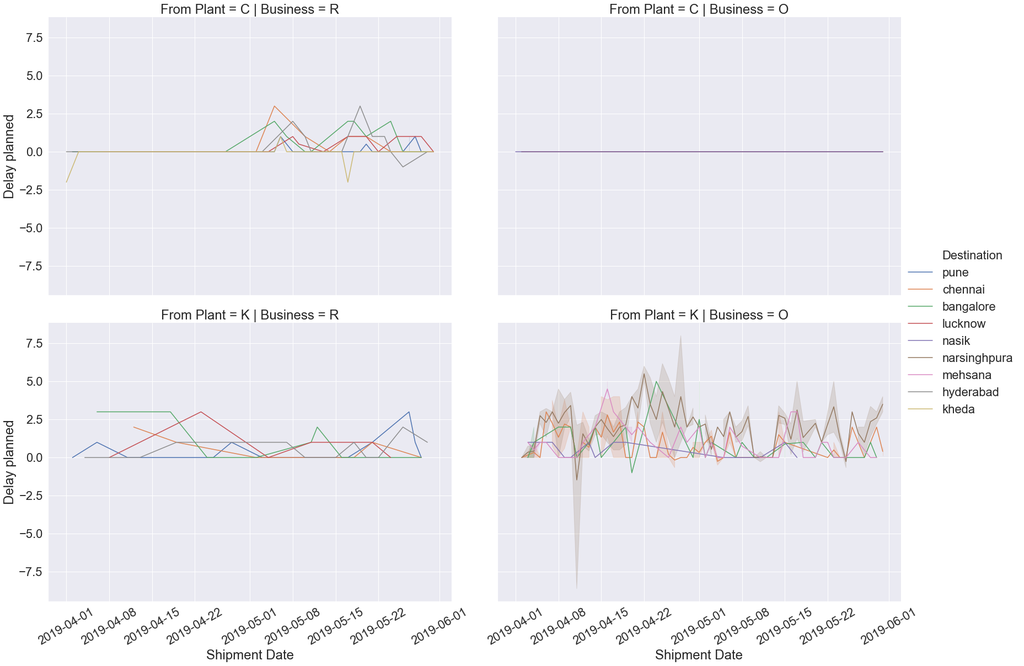

## Shipment delays shown for different products codes:

1. X85 shipping had delays in May from Plant C, and throught two months from Plant K.
2. X48 and X40 had delays mostly from Plant K.

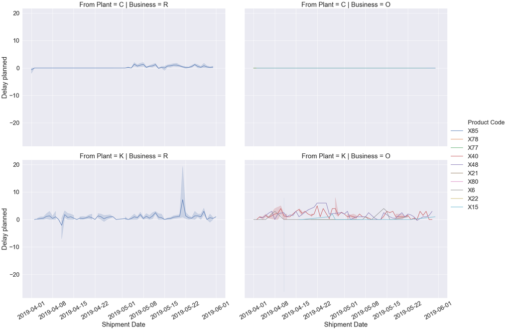

## Truck types and Delays

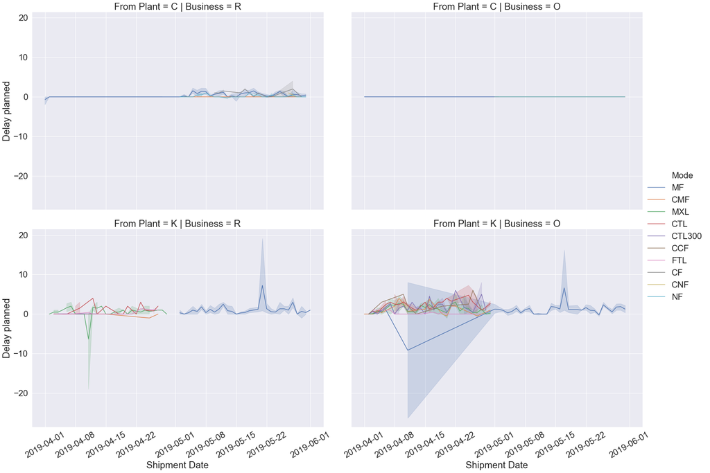

## 4. Truck states and Cities:

#### Truck states:

```
MH    792
HR    559
MP    439
NL    393
RJ    119
Name: truck_state, dtype: int64
```

#### Top truck cities

```
MP09    406
NL01    392
HR55    259
MH12    251
MH14    246
Name: truck_city, dtype: int64
```

#### Grouping data by truck states seeing shipment delay:

|  | Shipment Date | truck_state | From Plant | Delay planned |
| --- | --- | --- | --- | --- |
| 0 | 2019-04-01 | HR | C | 0.0 |
| 1 | 2019-04-01 | MH | C | 0.0 |
| 3 | 2019-04-01 | MP | K | 0.0 |
| 2 | 2019-04-01 | MP | C | -2.0 |
| 4 | 2019-04-02 | HR | C | 0.0 |
| ... | ... | ... | ... | ... |
| 634 | 2019-05-31 | MP | C | 0.0 |
| 636 | 2019-05-31 | NL | C | 0.0 |
| 638 | 2019-05-31 | RJ | K | 0.0 |
| 639 | 2019-05-31 | TN | C | 0.0 |
| 641 | 2019-06-01 | HR | K | 1.0 |

642 rows × 4 columns

#### Grouping data by truck cities seeing shipment delay:

|  | Shipment Date | From Plant | truck_city | Business | Delay planned |
| --- | --- | --- | --- | --- | --- |
| 0 | 2019-04-01 | C | HR55 | O | 0.0 |
| 1 | 2019-04-01 | C | HR55 | R | 0.0 |
| 2 | 2019-04-01 | C | MH04 | R | 0.0 |
| 3 | 2019-04-01 | C | MH42 | O | 0.0 |
| 5 | 2019-04-01 | K | MP09 | O | 0.0 |

```
Index(['MP09', 'NL01', 'HR55', 'MH12', 'MH14', 'HR38', 'RJ11'], dtype='object')
```

## Shipment delay wrt to truck cities:

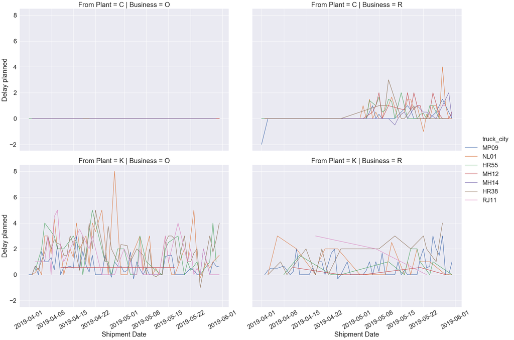

## 5. What kind of truck types different states have.

1. Maharashtra the most number of MF trucks, followed by HR, NL and MP.
2. Only Maharashtra had NF trucks.

```
Mode  truck_state
MF    MH             507
      HR             371
      NL             302
      MP             248
NF    MH             227
CTL   HR             101
MF    RJ              81
MXL   MP              77
MF    TS              59
      CG              53
Name: Mode, dtype: int64
```

## 6. Misc

### * 15 rows out total 2555 had Plan date earlier than confirmation date. Is this a data issue or it has some business implication?

### * Does extra items have anything to do with delays:

1. Independent correlation: 0.08005353178925198
2. Increasing correlation with more grouping 0.15411146832317568 -> 0.1618508193202881.
3. But gets flat at 16% and does not increase with more dimensions.

| Product Code | Shipment Date | Delay planned | Extra items |
| --- | --- | --- | --- |
| X6 | 2019-05-10 | 0 days 00:00:00 | 1.505600 |
|  | 2019-05-22 | 0 days 12:00:00 | 1.505600 |
| X85 | 2019-04-27 | 0 days 04:34:17.142857 | 2.935788 |
| X37 | 2019-04-10 | 0 days 00:00:00 | 3.011200 |
| X6 | 2019-05-08 | 0 days 08:00:00 | 4.337067 |
| ... | ... | ... | ... |
| X40 | 2019-05-06 | 2 days 00:00:00 | 1463.011200 |
|  | 2019-05-17 | 3 days 00:00:00 | 1463.011200 |
|  | 2019-05-21 | 1 days 00:00:00 | 1496.344533 |
|  | 2019-05-25 | 0 days 00:00:00 | 1523.011200 |
| X5 | 2019-05-22 | 4 days 00:00:00 | 1533.011200 |

556 rows × 2 columns

```
0.08005353178925198
```

```
0.15411146832317568
```

```
0.1618508193202881
```

```
0.1562375882781751
```

```
0.10605236775052089
```

### Do extra items have anything with delay? Not really, correlation could only go as high as 0.16. Including destination in the delay correlation with extra items introduces only dip in correlation everytime.

# Future:

1. With more data, we can use time series forecasting techniques, predict different product demands and truck types needed make the shipments.
2. As Vehicle numbers are given by RTOs in an ascending manner, we can find out how new a particular truck is and hence find out which engine type it has for instance BS5 or BS6 in recently.
3. With real time data on where a particular truck is we can provide insights on how to arrange trucks for a particular shipment in least time and cost.